# Impact of School Choice and Family Engagement on K-12 Educational Success

## Variable Identification and Classification

Our analysis requires careful identification of variables across four critical categories: outcome measures, school choice indicators, family engagement metrics, and demographic controls. We systematically reviewed the PFI codebook and identified relevant variables for each category.

```r
## Systematic Variable Identification with Actual Variable Names

# Outcome variables
outcome_vars <- c(
  "SEGRADES",   # Child's grades across all subjects (PRIMARY OUTCOME)
  "SEGRADEQ",   # Expected educational attainment
  "SEENJOY",    # School enjoyment
  "SEABSNT"     # School absences (alternative outcome)
)

# School choice variables - REQUIRED FOCUS AREA
school_choice_vars <- c(
  "SCCHOICE",   # Had choice of schools (KEY VARIABLE)
  "SPUBCHOIX",  # Public school choice
  "SCONSIDR",   # Schools considered
  "EDCPUB",     # Type of school (public/private indicator)
  "SCHLHRSWK",  # School hours per week
  "MOSTIMPT"    # Most important reason for school choice
)

# Family engagement - Homework (REQUIRED FOCUS)
homework_engagement_vars <- c(
  "FHHOME",     # Homework activities at home
  "FHWKHRS",    # Hours of homework per week
  "FHAMOUNT",   # Amount of homework
  "FHCAMT",     # Homework amount appropriate
  "FHPLACE",    # Has place for homework
  "FHCHECKX",   # Check homework completion
  "FHHELP"      # Help with homework
)

# Family engagement - School activities (REQUIRED FOCUS)
school_activity_vars <- c(
  "FSSPORTX",   # School sports participation
  "FSVOL",      # Volunteered at school
  "FSMTNG",     # Attended general school meeting
  "FSPTMTNG",   # Attended parent-teacher conference
  "FSATCNFN",   # Attended school conference
  "FSFUNDRS",   # Participated in fundraising
  "FSCOMMTE",   # Served on school committee
  "FSCOUNSLR",  # Met with school counselor
  "FSFREQ"      # Frequency of school involvement
)

# Parent-school communication variables
communication_vars <- c(
  "FSNOTESX",   # School notes/emails
  "FSMEMO",     # School memos
  "FCSCHOOL",   # Contact with school
  "FCTEACHR",   # Contact with teacher
  "FCSTDS",     # Discuss standards
  "FCORDER",    # Discuss order/discipline
  "FCSUPPRT"    # School support
)

# Home educational activities
home_activity_vars <- c(
  "FOSTORY2X",  # Tell stories to child
  "FOCRAFTS",   # Arts and crafts
  "FOGAMES",    # Play games
  "FOBUILDX",   # Building activities
  "FOSPORT",    # Sports activities
  "FORESPON",   # Discuss responsibilities
  "FOHISTX",    # Discuss history/heritage
  "FODINNERX",  # Family dinners
  "FOLIBRAYX",  # Visit library
  "FOBOOKSTX"   # Visit bookstore
)

# Demographic and control variables
demographic_vars <- c(
  "CDOBMM",     # Child's birth month
  "CDOBYY",     # Child's birth year
  "CSEX",       # Child's sex
  "ALLGRADEX",  # Current grade level
  "CSPEAKX",    # Language spoken
  "HHTOTALXX",  # Household total
  "RELATION",   # Relationship to child
  "P1REL",      # Parent 1 relationship
  "P1SEX",      # Parent 1 sex
  "P1MRSTA",    # Parent 1 marital status
  "P1EMPL",     # Parent 1 employment
  "P1HRSWK",    # Parent 1 hours worked
  "P1AGE",      # Parent 1 age
  "P2GUARD",    # Parent 2 guardian status
  "TTLHHINC",   # Total household income
  "OWNRNTHB",   # Own or rent home
  "CHLDNT",     # Number of children
  "DSBLTY",     # Disability status
  "HHPARN19X",  # Number of parents in household
  "NUMSIBSX",   # Number of siblings
  "PARGRADEX",  # Parent's highest education
  "RACEETH",    # Race/ethnicity
  "CENREG",     # Census region
  "ZIPLOCL"     # ZIP code locale
)

# Additional variables for analysis
other_important_vars <- c(
  "HDHEALTH",   # Child's health
  "SEFUTUREX",  # Future expectations
  "INTACC",     # Internet access
  "EINTNET"     # Internet use for education
)

# Compile all selected variables
all_selected_vars <- unique(c(outcome_vars, school_choice_vars, homework_engagement_vars,
                              school_activity_vars, communication_vars, home_activity_vars,
                              demographic_vars, other_important_vars))

cat("\n=== Variable Selection Summary ===\n")
```

```
##
## === Variable Selection Summary ===
```

```r
cat("Outcome variables identified:", length(outcome_vars), "\n")
```

```
## Outcome variables identified: 4
```

```r
cat("School choice variables:", length(school_choice_vars), "\n")
```

```
## School choice variables: 6
```

```r
cat("Homework engagement variables:", length(homework_engagement_vars), "\n")
```

```
## Homework engagement variables: 7
```

```r
cat("School activity variables:", length(school_activity_vars), "\n")
```

```
## School activity variables: 9
```

```r
cat("Communication variables:", length(communication_vars), "\n")
```

```
## Communication variables: 7
```

```r
cat("Home activity variables:", length(home_activity_vars), "\n")
```

```
## Home activity variables: 10
```

```r
cat("Demographic/control variables:", length(demographic_vars), "\n")
```

```
## Demographic/control variables: 24
```

```r
cat("Other important variables:", length(other_important_vars), "\n")
```

```
## Other important variables: 4
```

```r
cat("Total unique variables selected:", length(all_selected_vars), "\n")
```

```
## Total unique variables selected: 71
```

```r
## Verify Variable Availability and Create Working Dataset

# Check which selected variables are actually in the dataset
available_vars <- intersect(all_selected_vars, names(pfi_data))
missing_vars <- setdiff(all_selected_vars, names(pfi_data))

cat("\n=== Variable Availability Check ===\n")
```

```
##
## === Variable Availability Check ===
```

```r
cat("Variables found in dataset:", length(available_vars), "\n")
```

```
## Variables found in dataset: 71
```

```r
cat("Variables not found:", length(missing_vars), "\n")
```

```
## Variables not found: 0
```

```r
if(length(missing_vars) > 0) {
  cat("\nVariables not found in dataset:\n")
  print(missing_vars)
}

# Create initial working dataset with available variables
pfi_working <- pfi_data %>%
  dplyr::select(dplyr::all_of(available_vars))

cat("\nWorking dataset created with", ncol(pfi_working), "variables\n")
```

```
##
## Working dataset created with 71 variables
```

```r
# Display structure summary
cat("\n=== Working Dataset Structure ===\n")
```

```
##
## === Working Dataset Structure ===
```

```r
cat("Observations:", nrow(pfi_working), "\n")
```

```
## Observations: 16446
```

```r
cat("Variables:", ncol(pfi_working), "\n")
```

```
## Variables: 71
```

```r
cat("Complete cases:", sum(complete.cases(pfi_working)), "\n")
```

```
## Complete cases: 16446
```

```r
cat("Percentage complete:", round(sum(complete.cases(pfi_working))/nrow(pfi_working)*100, 2), "%\n")
```

```
## Percentage complete: 100 %
```

```r
## Data Type Verification and Key Variable Analysis

# Function to examine variable
examine_variable <- function(data, var_name, var_description = "") {
  if(var_name %in% names(data)) {
    cat(paste0("\n", var_name, " - ", var_description, "\n"))
    cat(paste0(rep("-", 50), collapse=""), "\n")

    # Get unique values
    unique_vals <- sort(unique(data[[var_name]]))
    n_unique <- length(unique_vals)

    if(n_unique <= 20) {
      cat("Unique values:", paste(unique_vals, collapse = ", "), "\n")

      # Show frequency table for categorical-like variables
      freq_table <- table(data[[var_name]], useNA = "ifany")
      prop_table <- prop.table(freq_table) * 100

      cat("\nFrequency distribution:\n")
      for(i in 1:length(freq_table)) {
        cat(sprintf("  %s: %d (%.1f%%)\n",
                   names(freq_table)[i],
                   freq_table[i],
                   prop_table[i]))
      }
    } else {
      cat("Continuous variable with", n_unique, "unique values\n")
      cat("\nSummary statistics:\n")
      print(summary(data[[var_name]]))
    }

    # Check for missing data codes
    potential_missing <- sum(data[[var_name]] %in% c(-1, -9, 99, 999), na.rm = TRUE)
    if(potential_missing > 0) {
      cat("\nWARNING: Found", potential_missing, "potential missing value codes\n")
    }
  } else {
    cat(paste0("\n", var_name, " - NOT FOUND in dataset\n"))
  }
}

# Examine key outcome variables
cat("\n========== KEY OUTCOME VARIABLES ==========\n")
```

```
##
## ========== KEY OUTCOME VARIABLES ==========
```

```r
examine_variable(pfi_working, "SEGRADES", "Student grades (Primary Outcome)")
```

```
##
## SEGRADES - Student grades (Primary Outcome)
## --------------------------------------------------
## Unique values: -1, 1, 2, 3, 4, 5
##
## Frequency distribution:
##   -1: 456 (2.8%)
##   1: 7866 (47.8%)
##   2: 4528 (27.5%)
##   3: 1345 (8.2%)
##   4: 263 (1.6%)
##   5: 1988 (12.1%)
##
## WARNING: Found 456 potential missing value codes
```

```r
examine_variable(pfi_working, "SEGRADEQ", "Expected educational attainment")
```

```
##
## SEGRADEQ - Expected educational attainment
## --------------------------------------------------
## Unique values: -1, 1, 2, 3, 4, 5
##
## Frequency distribution:
##   -1: 456 (2.8%)
##   1: 5428 (33.0%)
##   2: 5331 (32.4%)
##   3: 4468 (27.2%)
##   4: 682 (4.1%)
##   5: 81 (0.5%)
##
## WARNING: Found 456 potential missing value codes
```

```r
examine_variable(pfi_working, "SEENJOY", "School enjoyment")
```

```
##
## SEENJOY - School enjoyment
## --------------------------------------------------
## Unique values: -1, 1, 2, 3, 4
##
## Frequency distribution:
##   -1: 456 (2.8%)
##   1: 5854 (35.6%)
##   2: 8268 (50.3%)
##   3: 1506 (9.2%)
##   4: 362 (2.2%)
##
## WARNING: Found 456 potential missing value codes
```

```r
# Examine key school choice variables
cat("\n\n========== KEY SCHOOL CHOICE VARIABLES ==========\n")
```

```
##
##
## ========== KEY SCHOOL CHOICE VARIABLES ==========
```

```r
examine_variable(pfi_working, "SCCHOICE", "Had choice of schools")
```

```
##
## SCCHOICE - Had choice of schools
## --------------------------------------------------
## Unique values: -1, 1, 2
##
## Frequency distribution:
##   -1: 456 (2.8%)
##   1: 10182 (61.9%)
##   2: 5808 (35.3%)
##
## WARNING: Found 456 potential missing value codes
```

```r
examine_variable(pfi_working, "SPUBCHOIX", "Public school choice")
```

```
##
## SPUBCHOIX - Public school choice
## --------------------------------------------------
## Unique values: -1, 1, 2, 3
##
## Frequency distribution:
##   -1: 456 (2.8%)
##   1: 5731 (34.8%)
##   2: 6050 (36.8%)
##   3: 4209 (25.6%)
##
## WARNING: Found 456 potential missing value codes
```

```r
examine_variable(pfi_working, "EDCPUB", "School type")
```

```
##
## EDCPUB - School type
## --------------------------------------------------
## Unique values: 1, 2
##
## Frequency distribution:
##   1: 14057 (85.5%)
##   2: 2389 (14.5%)
```

```r
# Examine key engagement variables
cat("\n\n========== KEY ENGAGEMENT VARIABLES ==========\n")
```

```
##
##
## ========== KEY ENGAGEMENT VARIABLES ==========
```

```r
examine_variable(pfi_working, "FHHELP", "Homework help")
```

```
##
## FHHELP - Homework help
## --------------------------------------------------
## Unique values: -1, 1, 2, 3, 4, 5
##
## Frequency distribution:
##   -1: 1513 (9.2%)
##   1: 4726 (28.7%)
##   2: 4146 (25.2%)
##   3: 2881 (17.5%)
##   4: 1337 (8.1%)
##   5: 1843 (11.2%)
##
## WARNING: Found 1513 potential missing value codes
```

```r
examine_variable(pfi_working, "FSVOL", "Volunteer at school")
```

```
##
## FSVOL - Volunteer at school
## --------------------------------------------------
## Unique values: -1, 1, 2
##
## Frequency distribution:
##   -1: 663 (4.0%)
##   1: 6670 (40.6%)
##   2: 9113 (55.4%)
##
## WARNING: Found 663 potential missing value codes
```

```r
examine_variable(pfi_working, "FSPTMTNG", "Parent-teacher conference")
```

```
##
## FSPTMTNG - Parent-teacher conference
## --------------------------------------------------
## Unique values: -1, 1, 2
##
## Frequency distribution:
##   -1: 663 (4.0%)
##   1: 7148 (43.5%)
##   2: 8635 (52.5%)
##
## WARNING: Found 663 potential missing value codes
```

```r
## Missing Data Analysis
library(tidyverse)

# Calculate missing data for all variables
missing_summary <- pfi_working %>%
  summarise_all(~sum(is.na(.) | . %in% c(-1, -9, 99, 999))) %>%
  pivot_longer(everything(), names_to = "Variable", values_to = "Missing_Count") %>%
  mutate(
    Missing_Percent = round(Missing_Count / nrow(pfi_working) * 100, 2),
    Category = case_when(
      Variable %in% outcome_vars ~ "Outcome",
      Variable %in% school_choice_vars ~ "School Choice",
      Variable %in% homework_engagement_vars ~ "Homework",
      Variable %in% school_activity_vars ~ "School Activities",
      Variable %in% communication_vars ~ "Communication",
      Variable %in% home_activity_vars ~ "Home Activities",
      Variable %in% demographic_vars ~ "Demographic",
      TRUE ~ "Other"
    )
  ) %>%
  arrange(Category, Missing_Percent)

# Summary by category
missing_by_category <- missing_summary %>%
  group_by(Category) %>%
  summarise(
    Variables = n(),
    Avg_Missing = round(mean(Missing_Percent), 2),
    Min_Missing = round(min(Missing_Percent), 2),
    Max_Missing = round(max(Missing_Percent), 2)
  ) %>%
  arrange(Avg_Missing)

kable(missing_by_category,
      caption = "Missing Data Summary by Variable Category",
      col.names = c("Category", "# Variables", "Avg % Missing",
                    "Min % Missing", "Max % Missing")) %>%
  kable_styling(bootstrap_options = c("striped", "hover"),
                full_width = FALSE,
                position = "center")
```

Missing Data Summary by Variable Category

| Category | # Variables | Avg % Missing | Min % Missing | Max % Missing |
| --- | --- | --- | --- | --- |
| Home Activities | 10 | 0.00 | 0.00 | 0.00 |
| Other | 4 | 0.80 | 0.00 | 3.19 |
| Demographic | 24 | 0.83 | 0.00 | 19.96 |
| Communication | 7 | 2.59 | 2.59 | 2.59 |
| Outcome | 4 | 2.77 | 2.77 | 2.77 |
| School Activities | 9 | 4.05 | 4.03 | 4.25 |
| Homework | 7 | 8.26 | 2.59 | 9.20 |
| School Choice | 6 | 17.38 | 0.00 | 93.18 |

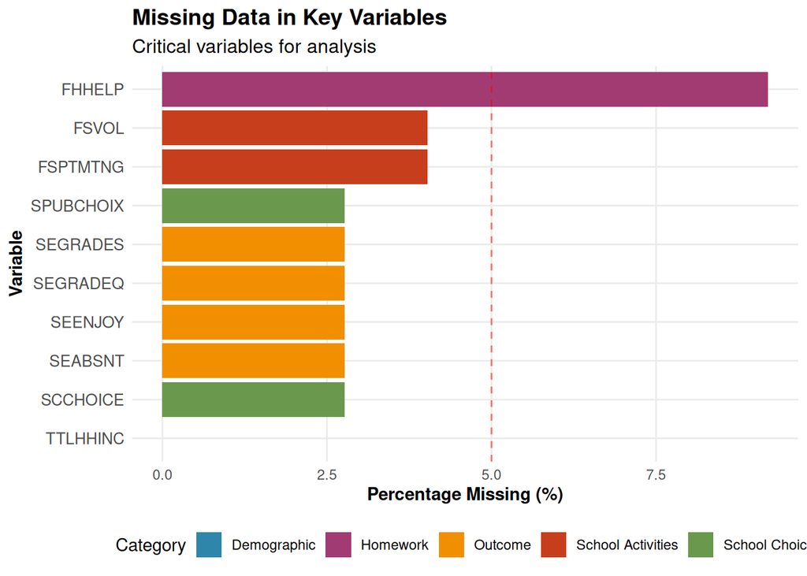

```r
# Visualize missing data patterns for key variables
key_vars_missing <- missing_summary %>%
  filter(Variable %in% c(outcome_vars,
                         c("SCCHOICE", "SPUBCHOIX", "FHHELP",
                           "FSVOL", "FSPTMTNG", "TTLHHINC"))) %>%
  ggplot(aes(x = reorder(Variable, Missing_Percent),
             y = Missing_Percent,
             fill = Category)) +
  geom_bar(stat = "identity") +
  coord_flip() +
  scale_fill_manual(values = project_colors) +
  labs(
    title = "Missing Data in Key Variables",
    subtitle = "Critical variables for analysis",
    x = "Variable",
    y = "Percentage Missing (%)",
    fill = "Category"
  ) +
  geom_hline(yintercept = 5, linetype = "dashed", color = "red", alpha = 0.5) +
  theme(axis.text.y = element_text(size = 10))

print(key_vars_missing)
```

## Feature Engineering Planning

Based on our variable exploration, we will create several engineered features to better capture the relationships between school choice, family engagement, and academic success.

```r
## Feature Engineering Implementation

# Create engineered features
pfi_engineered <- pfi_working %>%
  mutate(
    # Binary academic success
    success_binary = case_when(
      SEGRADES %in% c(1, 2) ~ 1,
      SEGRADES %in% c(3, 4) ~ 0,
      TRUE ~ NA_real_
    ),

    # School activity engagement count
    engagement_count = rowSums(
      dplyr::select(., FSSPORTX, FSVOL, FSMTNG, FSPTMTNG, FSATCNFN,
                    FSFUNDRS, FSCOMMTE, FSCOUNSLR) == 1,
      na.rm = TRUE
    ),

    # Homework intensity index
    homework_intensity = rowMeans(
      dplyr::select(., FHHOME, FHCHECKX, FHHELP),
      na.rm = TRUE
    ),

    # School involvement index
    school_involvement = rowMeans(
      dplyr::select(., FSVOL, FSMTNG, FSPTMTNG, FSCOMMTE),
      na.rm = TRUE
    ),

    # Communication frequency index
    communication_index = rowMeans(
      dplyr::select(., FCSCHOOL, FCTEACHR, FSNOTESX),
      na.rm = TRUE
    ),

    # Home enrichment activities
    enrichment_count = rowSums(
      dplyr::select(., FOSTORY2X, FOCRAFTS, FOGAMES, FOBUILDX,
                    FOSPORT, FOLIBRAYX, FOBOOKSTX) == 1,
      na.rm = TRUE
    ),

    # School choice indicator
    has_choice = ifelse(SCCHOICE == 1, 1, 0),

    # Child age
    child_age = 2019 - as.numeric(CDOBYY)
  )


# Summary of engineered features
engineered_summary <- data.frame(
  Feature = c("success_binary", "engagement_count", "homework_intensity",
              "school_involvement", "communication_index", "enrichment_count"),
  Description = c(
    "Binary outcome: 1 if grades A/B, 0 if C/D",
    "Count of school activities participated in",
    "Average homework engagement (0-1 scale)",
    "Average school involvement (0-1 scale)",
    "Average parent-school communication (0-1 scale)",
    "Count of home enrichment activities"
  ),
  Mean = c(
    mean(pfi_engineered$success_binary, na.rm = TRUE),
    mean(pfi_engineered$engagement_count, na.rm = TRUE),
    mean(pfi_engineered$homework_intensity, na.rm = TRUE),
    mean(pfi_engineered$school_involvement, na.rm = TRUE),
    mean(pfi_engineered$communication_index, na.rm = TRUE),
    mean(pfi_engineered$enrichment_count, na.rm = TRUE)
  ),
  SD = c(
    sd(pfi_engineered$success_binary, na.rm = TRUE),
    sd(pfi_engineered$engagement_count, na.rm = TRUE),
    sd(pfi_engineered$homework_intensity, na.rm = TRUE),
    sd(pfi_engineered$school_involvement, na.rm = TRUE),
    sd(pfi_engineered$communication_index, na.rm = TRUE),
    sd(pfi_engineered$enrichment_count, na.rm = TRUE)
  )
)

kable(engineered_summary,
      caption = "Summary of Engineered Features",
      col.names = c("Feature", "Description", "Mean", "SD"),
      digits = 3) %>%
  kable_styling(bootstrap_options = c("striped", "hover"),
                full_width = FALSE,
                position = "center")
```

Summary of Engineered Features

[output not shown]

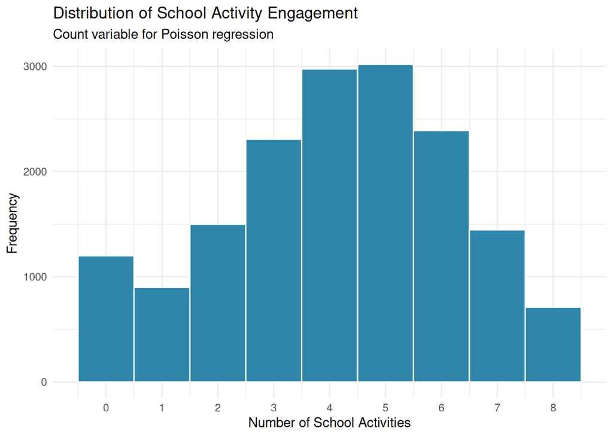

```r
# Visualize distribution of engagement count (for Poisson regression)
engagement_dist <- ggplot(pfi_engineered, aes(x = engagement_count)) +
  geom_histogram(binwidth = 1, fill = project_colors[1], color = "white") +
  labs(
    title = "Distribution of School Activity Engagement",
    subtitle = "Count variable for Poisson regression",
    x = "Number of School Activities",
    y = "Frequency"
  ) +
  scale_x_continuous(breaks = 0:8) +
  theme_minimal()

print(engagement_dist)
```

```r
# Check for overdispersion in count data
cat("\n=== Poisson Regression Preparation ===\n")
```

```
##
## === Poisson Regression Preparation ===
```

```r
cat("Engagement count statistics:\n")
```

```
## Engagement count statistics:
```

```r
cat("Mean:", mean(pfi_engineered$engagement_count, na.rm = TRUE), "\n")
```

```
## Mean: 4.132
```

```r
cat("Variance:", var(pfi_engineered$engagement_count, na.rm = TRUE), "\n")
```

```
## Variance: 4.394
```

```r
cat("Variance/Mean ratio:",
    var(pfi_engineered$engagement_count, na.rm = TRUE) /
    mean(pfi_engineered$engagement_count, na.rm = TRUE), "\n")
```

```
## Variance/Mean ratio: 1.063
```

```r
if(var(pfi_engineered$engagement_count, na.rm = TRUE) >
   mean(pfi_engineered$engagement_count, na.rm = TRUE)) {
  cat("Note: Variance > Mean suggests overdispersion - consider negative binomial\n")
}
```

```
## Note: Variance > Mean suggests overdispersion - consider negative binomial
```

## Data Quality Assessment Summary

We have completed a comprehensive assessment of data quality, identifying patterns that will inform our modeling strategy.

```r
## Create Comprehensive Data Quality Report

# Overall data quality metrics
quality_report <- list(
  total_obs = nrow(pfi_data),
  working_vars = ncol(pfi_working),
  engineered_vars = ncol(pfi_engineered) - ncol(pfi_working),
  complete_cases = sum(complete.cases(pfi_engineered)),
  complete_pct = round(sum(complete.cases(pfi_engineered))/nrow(pfi_engineered)*100, 2),

  # Outcome variable quality
  outcome_missing = round(sum(is.na(pfi_engineered$SEGRADES))/nrow(pfi_engineered)*100, 2),
  binary_outcome_dist = round(prop.table(table(pfi_engineered$success_binary))*100, 2),

  # Key predictor quality
  choice_missing = round(sum(is.na(pfi_engineered$SCCHOICE))/nrow(pfi_engineered)*100, 2),
  homework_missing = round(sum(is.na(pfi_engineered$FHHELP))/nrow(pfi_engineered)*100, 2),

  # Engagement measures
  mean_engagement = round(mean(pfi_engineered$engagement_count, na.rm = TRUE), 2),
  max_engagement = max(pfi_engineered$engagement_count, na.rm = TRUE)
)

# Create formatted quality report table
quality_df <- data.frame(
  Metric = c("Total Observations",
             "Working Variables",
             "Engineered Features",
             "Complete Cases",
             "Complete Cases %",
             "Outcome Missing %",
             "Success Rate (Binary)",
             "School Choice Missing %",
             "Homework Help Missing %",
             "Mean Engagement Count",
             "Max Engagement Count"),
  Value = c(quality_report$total_obs,
           quality_report$working_vars,
           quality_report$engineered_vars,
           quality_report$complete_cases,
           paste0(quality_report$complete_pct, "%"),
           paste0(quality_report$outcome_missing, "%"),
           paste0(quality_report$binary_outcome_dist[2], "%"),
           paste0(quality_report$choice_missing, "%"),
           paste0(quality_report$homework_missing, "%"),
           quality_report$mean_engagement,
           quality_report$max_engagement)
)

kable(quality_df,
      caption = "Data Quality Assessment Summary",
      col.names = c("Quality Metric", "Value"),
      align = c("l", "r")) %>%
  kable_styling(bootstrap_options = c("striped", "hover"),
                full_width = FALSE,
                position = "center")
```

Data Quality Assessment Summary

| Quality Metric | Value |
| --- | --- |
| Total Observations | 16446 |
| Working Variables | 71 |
| Engineered Features | 8 |
| Complete Cases | 14002 |
| Complete Cases % | 85.14% |
| Outcome Missing % | 0% |
| Success Rate (Binary) | 88.52% |
| School Choice Missing % | 0% |
| Homework Help Missing % | 0% |
| Mean Engagement Count | 4.13 |
| Max Engagement Count | 8 |

## Key Decisions and Preparation for Modeling

Based on our comprehensive data understanding phase, we have made the following strategic decisions:

```r
## Document Final Decisions for Phase 2

decisions <- list(
  "Primary Outcome" = "SEGRADES serves as our primary outcome, with binary version (A/B vs C/D)
                       for logistic regression and original 4-category for multinomial regression",

  "Count Outcome" = "engagement_count (0-8 scale) created from school activity variables
                     for Poisson regression demonstration",

  "School Choice Variables" = "SCCHOICE (had choice) and SPUBCHOIX (public choice) as primary indicators,
                              supplemented by EDCPUB for school type analysis",

  "Homework Engagement" = "FHHELP (help frequency), FHCHECKX (checking), and composite homework_intensity
                          index capture homework support patterns",

  "School Activities" = "Individual activities (FSVOL, FSPTMTNG, etc.) plus school_involvement
                        index measure school engagement",

  "Control Strategy" = "TTLHHINC (income), PARGRADEX (parent education), CSEX, ALLGRADEX,
                       and RACEETH as key demographic controls",

  "Missing Data" = "Variables with <10% missing retained; missing value codes (-1, -9, 99)
                    converted to NA; imputation planned for modeling phase",

  "Interaction Terms" = "Plan to explore SCCHOICE × engagement_count and TTLHHINC × homework_intensity
                        interactions in Phase 2"
)

# Create formatted decision table
decision_df <- data.frame(
  Decision_Area = names(decisions),
  Strategy = unlist(decisions),
  stringsAsFactors = FALSE
)

kable(decision_df,
      caption = "Strategic Decisions for Modeling Phase",
      col.names = c("Decision Area", "Strategy")) %>%
  kable_styling(bootstrap_options = c("striped", "hover"),
                full_width = FALSE,
                position = "center") %>%
  column_spec(1, bold = TRUE, width = "3cm") %>%
  column_spec(2, width = "12cm")
```

Strategic Decisions for Modeling Phase

[output not shown]

```r
## Save Clean Dataset for Next Phase

# Final data preparation
pfi_clean <- pfi_engineered %>%
  # Replace missing value codes with NA
  mutate(across(everything(), ~ifelse(. %in% c(-1, -9, 99, 999), NA, .)))

# Remove variables with >30% missing
high_missing <- missing_summary %>%
  filter(Missing_Percent > 30) %>%
  pull(Variable)

if(length(high_missing) > 0) {
  cat("\nRemoving", length(high_missing), "variables with >30% missing:\n")
  print(high_missing)
  pfi_clean <- pfi_clean %>%
  dplyr::select(-dplyr::all_of(high_missing))
}
```

```
##
## Removing 1 variables with >30% missing:
## [1] "MOSTIMPT"
```

```r
# Save the dataset
write_csv(pfi_clean, "pfi_phase1_clean.csv")
saveRDS(pfi_clean, "pfi_phase1_clean.rds")

# Create final summary
final_summary <- data.frame(
  Stage = c("Original 2019 Data",
            "Variable Selection",
            "After Engineering",
            "Final Clean Dataset"),
  Observations = c(nrow(pfi_data),
                  nrow(pfi_working),
                  nrow(pfi_engineered),
                  nrow(pfi_clean)),
  Variables = c(ncol(pfi_data),
               ncol(pfi_working),
               ncol(pfi_engineered),
               ncol(pfi_clean))
)

kable(final_summary,
      caption = "Data Transformation Summary",
      align = c("l", "r", "r")) %>%
  kable_styling(bootstrap_options = c("striped", "hover"),
                full_width = FALSE,
                position = "center")
```

Data Transformation Summary

| Stage | Observations | Variables |
| --- | --- | --- |
| Original 2019 Data | 16446 | 828 |
| Variable Selection | 16446 | 71 |
| After Engineering | 16446 | 79 |
| Final Clean Dataset | 16446 | 78 |

```r
cat("\n✓ Phase 1 Complete: Clean dataset saved as 'pfi_phase1_clean.csv' and '.rds'\n")
```

```
##
## ✓ Phase 1 Complete: Clean dataset saved as 'pfi_phase1_clean.csv' and '.rds'
```

```r
engineered_summary_complete <- data.frame(
  Feature = c("success_binary", "engagement_count", "homework_intensity",
              "school_involvement", "communication_index", "enrichment_count",
              "has_choice", "child_age"),
  Description = c(
    "Binary outcome: 1 if grades A/B, 0 if C/D",
    "Count of school activities participated in (0-8)",
    "Average homework engagement frequency",
    "Average school involvement frequency",
    "Average parent-school communication frequency",
    "Count of home enrichment activities (0-7)",
    "Binary indicator: 1 if had school choice, 0 otherwise",
    "Child's age calculated from birth year"
  ),
  Type = c("Outcome", "Composite Index", "Composite Index",
           "Composite Index", "Composite Index", "Composite Index",
           "Simple Recode", "Simple Calculation"),
  Mean = c(
    round(mean(pfi_engineered$success_binary, na.rm = TRUE), 2),
    round(mean(pfi_engineered$engagement_count, na.rm = TRUE), 2),
    round(mean(pfi_engineered$homework_intensity, na.rm = TRUE), 2),
    round(mean(pfi_engineered$school_involvement, na.rm = TRUE), 2),
    round(mean(pfi_engineered$communication_index, na.rm = TRUE), 2),
    round(mean(pfi_engineered$enrichment_count, na.rm = TRUE), 2),
    round(mean(pfi_engineered$has_choice, na.rm = TRUE), 2),
    round(mean(pfi_engineered$child_age, na.rm = TRUE), 2)
  ),
  SD = c(
    round(sd(pfi_engineered$success_binary, na.rm = TRUE), 2),
    round(sd(pfi_engineered$engagement_count, na.rm = TRUE), 2),
    round(sd(pfi_engineered$homework_intensity, na.rm = TRUE), 2),
    round(sd(pfi_engineered$school_involvement, na.rm = TRUE), 2),
    round(sd(pfi_engineered$communication_index, na.rm = TRUE), 2),
    round(sd(pfi_engineered$enrichment_count, na.rm = TRUE), 2),
    round(sd(pfi_engineered$has_choice, na.rm = TRUE), 2),
    round(sd(pfi_engineered$child_age, na.rm = TRUE), 2)
  )
)

kable(engineered_summary_complete,
      caption = "Table: All Engineered Features",
      col.names = c("Feature", "Description", "Type", "Mean", "SD"),
      digits = 2) %>%
  kable_styling(bootstrap_options = c("striped", "hover"),
                full_width = FALSE) %>%
  row_spec(1:6, background = "#f0f8ff")
```

Table: All Engineered Features

| Feature | Description | Type | Mean | SD |
| --- | --- | --- | --- | --- |
| success_binary | Binary outcome: 1 if grades A/B, 0 if C/D | Outcome | 0.89 | 0.32 |
| engagement_count | Count of school activities participated in (0-8) | Composite Index | 4.13 | 2.10 |
| homework_intensity | Average homework engagement frequency | Composite Index | 2.72 | 0.96 |
| school_involvement | Average school involvement frequency | Composite Index | 1.43 | 0.57 |
| communication_index | Average parent-school communication frequency | Composite Index | 1.35 | 0.58 |
| enrichment_count | Count of home enrichment activities (0-7) | Composite Index | 3.49 | 1.96 |
| has_choice | Binary indicator: 1 if had school choice, 0 otherwise | Simple Recode | 0.62 | 0.49 |
| child_age | Child’s age calculated from birth year | Simple Calculation | 13.06 | 3.84 |